# Data Transformations

Andrew Bell

2022

[figure not shown]

## Learning Objectives

- Become familiar with data transformation functions
- Understand how to deal with na’s
- Learn how to use the package DataEditR to do simple edits to data

## Data Transformations

In the previous session, we explored the friends_info dataset. What analysis and/or insight was not possible with the ggplot() code that we learned? What core grammar of graphics building block did we not talk about?

### dplyr basics (modified from r4ds 5.1.3)

In this section we will learn 5 basic data manipulation / transformation functions.

- Pick observations by their values ([`filter()`](https://rdrr.io/r/stats/filter.html)).
- Reorder the rows (`arrange()`).
- Pick variables by their names (`select()`).
- Create new variables with functions of existing variables (`mutate()`).
- Collapse many values down to a single summary (`summarise()`).

These can all be used in conjunction with `group_by()` which changes the scope of each function from operating on the entire dataset to operating on it group-by-group.

### Filtering

What if we wanted to learn more about those those outliers that we identified in our Friend’s episode scatterplot of imdb rating and views? We can use some basic data transformation functions to quickly filter our data to learn more about those specific episodes.

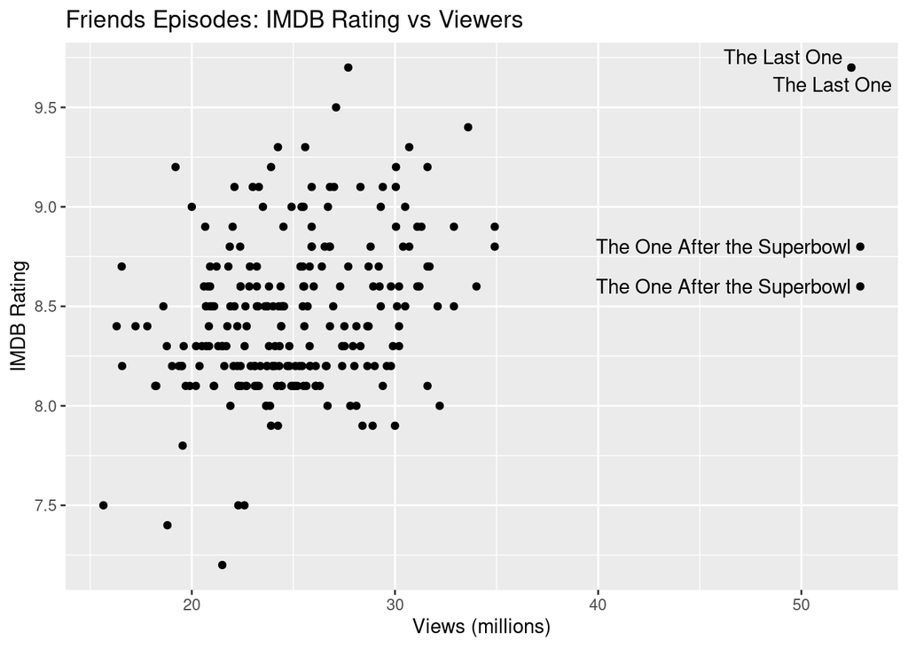

```r
first_viz <-  ggplot(data = friends_info,
                    mapping = aes(x = us_views_millions, y = imdb_rating))+
  geom_point()+
  geom_text_repel(data = filter(friends_info, us_views_millions > 40),
                                         mapping = aes(label = title))+
  labs(title = "Friends Episodes: IMDB Rating vs Viewers",
       x = "Views (millions)",
       y = "IMDB Rating")+
  scale_y_continuous(breaks = seq(7,10.5, by = 0.5))

first_viz
```

What new function did we use in the code above to only show the episode title text on the plot? Filter!

We can use filter to filter our tables

```r
filter_friends <- filter(friends_info, us_views_millions >40)

?kable()

kable(filter_friends, format = "html")
```

| season | episode | title | directed_by | written_by | air_date | us_views_millions | imdb_rating |
| --- | --- | --- | --- | --- | --- | --- | --- |
| 2 | 12 | The One After the Superbowl | Michael Lembeck | Jeffrey Astrof & Mike SikowitzMichael Borkow | 1996-01-28 | 52.90 | 8.6 |
| 2 | 13 | The One After the Superbowl | Michael Lembeck | Jeffrey Astrof & Mike SikowitzMichael Borkow | 1996-01-28 | 52.90 | 8.8 |
| 10 | 17 | The Last One | Kevin S. Bright | Marta Kauffman & David Crane | 2004-05-06 | 52.46 | 9.7 |
| 10 | 18 | The Last One | Kevin S. Bright | Marta Kauffman & David Crane | 2004-05-06 | 52.46 | 9.7 |

```r
#curious about kable()? Use the ?kable() to read the function's documentation
```

### Arrange rows with arrange()

Suppose we’d like to just have a table of Friend’s episodes that is sorted (excel term) / arranged by number of views. We do that with the arrange() function.

```r
arrange_friends <- arrange(friends_info, desc(us_views_millions))

arrange_friends
```

```
## # A tibble: 236 × 8
##    season episode title    directed_by  written_by   air_date   us_views_millio…
##     <dbl>   <dbl> <chr>    <chr>        <chr>        <date>                <dbl>
##  1      2      12 The One… Michael Lem… Jeffrey Ast… 1996-01-28             52.9
##  2      2      13 The One… Michael Lem… Jeffrey Ast… 1996-01-28             52.9
##  3     10      17 The Las… Kevin S. Br… Marta Kauff… 2004-05-06             52.5
##  4     10      18 The Las… Kevin S. Br… Marta Kauff… 2004-05-06             52.5
##  5      8      23 The One… Kevin S. Br… Scott Silve… 2002-05-16             34.9
##  6      8      24 The One… Kevin S. Br… Scott Silve… 2002-05-16             34.9
##  7      9       1 The One… Kevin S. Br… Sherry Bils… 2002-09-26             34.0
##  8      2      14 The One… James Burro… Alexa Junge  1996-02-01             33.6
##  9      2       8 The One… Mary Kay Pl… David Crane… 1995-11-16             32.9
## 10      2      15 The One… Michael Lem… Michael Cur… 1996-02-08             32.9
## # … with 226 more rows, and 1 more variable: imdb_rating <dbl>
```

There is also a package that allows for this type of sorting dynamically. The DT package creates the ability to add filtering, pagination, and sorting to HTML tables. Users can slice, scroll through, and arrange tables in ways that help them to make sense of your results.

```r
datatable(friends_info)
```

|  | season | episode | title | directed_by | written_by | air_date | us_views_millions | imdb_rating |
| --- | --- | --- | --- | --- | --- | --- | --- | --- |
| 1 | 1 | 1 | The Pilot | James Burrows | David Crane &amp; Marta Kauffman | 1994-09-22 | 21.5 | 8.3 |
| 2 | 1 | 2 | The One with the Sonogram at the End | James Burrows | David Crane &amp; Marta Kauffman | 1994-09-29 | 20.2 | 8.1 |
| 3 | 1 | 3 | The One with the Thumb | James Burrows | Jeffrey Astrof &amp; Mike Sikowitz | 1994-10-06 | 19.5 | 8.2 |
| 4 | 1 | 4 | The One with George Stephanopoulos | James Burrows | Alexa Junge | 1994-10-13 | 19.7 | 8.1 |
| 5 | 1 | 5 | The One with the East German Laundry Detergent | Pamela Fryman | Jeff Greenstein &amp; Jeff Strauss | 1994-10-20 | 18.6 | 8.5 |
| 6 | 1 | 6 | The One with the Butt | Arlene Sanford | Adam Chase &amp; Ira Ungerleider | 1994-10-27 | 18.2 | 8.1 |
| 7 | 1 | 7 | The One with the Blackout | James Burrows | Jeffrey Astrof &amp; Mike Sikowitz | 1994-11-03 | 23.5 | 9 |
| 8 | 1 | 8 | The One Where Nana Dies Twice | James Burrows | Marta Kauffman &amp; David Crane | 1994-11-10 | 21.1 | 8.1 |
| 9 | 1 | 9 | The One Where Underdog Gets Away | James Burrows | Jeff Greenstein &amp; Jeff Strauss | 1994-11-17 | 23.1 | 8.2 |
| 10 | 1 | 10 | The One with the Monkey | Peter Bonerz | Adam Chase &amp; Ira Ungerleider | 1994-12-15 | 19.9 | 8.1 |

[output cut: 226 more lines]

### Select columns

Notice how both of the above tables have readability challenges due to be too ‘wide’ (too many columns). If the purpose of this table is just to show a subset of our variables - let’s say - views, title, imdb rating, and season, then we can use the function `select()`.

```r
select_friends_info <- select(friends_info, title, us_views_millions, imdb_rating, season)

datatable(select_friends_info)
```

|  | title | us_views_millions | imdb_rating | season |
| --- | --- | --- | --- | --- |
| 1 | The Pilot | 21.5 | 8.3 | 1 |
| 2 | The One with the Sonogram at the End | 20.2 | 8.1 | 1 |
| 3 | The One with the Thumb | 19.5 | 8.2 | 1 |
| 4 | The One with George Stephanopoulos | 19.7 | 8.1 | 1 |
| 5 | The One with the East German Laundry Detergent | 18.6 | 8.5 | 1 |
| 6 | The One with the Butt | 18.2 | 8.1 | 1 |
| 7 | The One with the Blackout | 23.5 | 9 | 1 |
| 8 | The One Where Nana Dies Twice | 21.1 | 8.1 | 1 |
| 9 | The One Where Underdog Gets Away | 23.1 | 8.2 | 1 |
| 10 | The One with the Monkey | 19.9 | 8.1 | 1 |

[output cut: 226 more lines]

The `select()` function works with a number of ‘helper’ functions:

- `starts_with("t")`: matches names that begin with “t”.
- `ends_with("season")`: matches names that end with “season”.
- `contains("view")`: matches names that contain “view”.

### Add new variables with **`mutate()`**

`mutate()` is a great way to add new columns (to the end of your dataset) to your data.

Let’s say we want to make a new value that is a ratio of the views and imdb_rating. This ratio is a simple way of determining what is the ‘best’ Friend’s episode.

```r
friends_ratio <- mutate(friends_info,
                        best = us_views_millions / imdb_rating)

friends_ratio <- select(friends_ratio, best, title)

datatable(friends_ratio)
```

|  | best | title |
| --- | --- | --- |
| 1 | 2.59036144578313 | The Pilot |
| 2 | 2.49382716049383 | The One with the Sonogram at the End |
| 3 | 2.37804878048781 | The One with the Thumb |
| 4 | 2.4320987654321 | The One with George Stephanopoulos |
| 5 | 2.18823529411765 | The One with the East German Laundry Detergent |
| 6 | 2.24691358024691 | The One with the Butt |
| 7 | 2.61111111111111 | The One with the Blackout |
| 8 | 2.60493827160494 | The One Where Nana Dies Twice |
| 9 | 2.81707317073171 | The One Where Underdog Gets Away |
| 10 | 2.45679012345679 | The One with the Monkey |

[output cut: 226 more lines]

### Grouped summaries with **`summarise()`**

You may have noticed that there are some “double” episodes - episodes that have two rows. These were hour long episodes that are represented twice in our data. How could we collapse the data so that the the views and rating are averaged across the two parts of the double episodes?

We can use the summarise() function in conjunction with group_by(). This changes the unit of analysis from the complete dataset to individual groups - in this case we want to group by ‘title’ and summarise the means of views and rating.

```r
title_friends <- group_by(friends_info, title)

title_friends <- summarise(title_friends,
                           mean_views = mean(us_views_millions),
                           mean_rating = mean(imdb_rating))

arrange(title_friends, desc(mean_views))
```

```
## # A tibble: 227 × 3
##    title                                    mean_views mean_rating
##    <chr>                                         <dbl>       <dbl>
##  1 The One After the Superbowl                    52.9        8.7
##  2 The Last One                                   52.5        9.7
##  3 The One Where Rachel Has a Baby                34.9        8.85
##  4 The One Where No One Proposes                  34.0        8.6
##  5 The One with the Prom Video                    33.6        9.4
##  6 The One Where Ross and Rachel...You Know       32.9        8.9
##  7 The One with the List                          32.9        8.5
##  8 The One with Russ                              32.2        8
##  9 The One with Ross's New Girlfriend             32.1        8.5
## 10 The One After 'I Do'                           31.7        8.7
## # … with 217 more rows
```

```r
datatable(title_friends)
```

|  | title | mean_views | mean_rating |
| --- | --- | --- | --- |
| 1 | The Last One | 52.46 | 9.7 |
| 2 | The One After 'I Do' | 31.7 | 8.7 |
| 3 | The One After Joey and Rachel Kiss | 24.54 | 8.5 |
| 4 | The One After Ross Says Rachel | 31.1 | 8.9 |
| 5 | The One After the Superbowl | 52.9 | 8.7 |
| 6 | The One After Vegas | 27.7 | 8.7 |
| 7 | The One at the Beach | 28.8 | 8.8 |
| 8 | The One Hundredth | 26.8 | 8.8 |
| 9 | The One in Barbados | 25.46 | 8.6 |
| 10 | The One in Massapequa | 22.05 | 8.2 |

[output cut: 217 more lines]

Suppose we want to better understand which Director had the highest mean_rating?

### Combining operations with a pipe

Suppose we want to look at the mean IMDB rating by season. What kind of data transformations and/or geom_layer might we need to run on the data?

```r
#option number 1 - generate the mean rating using dplyr functions and plot resulting values in bar plot
IMDB_byseason <- friends_info%>%
  group_by(season)%>%
  summarise(mean_IMDB = mean(imdb_rating))%>%
  arrange(desc(mean_IMDB))

IMDB_byseason
```

```
## # A tibble: 10 × 2
##    season mean_IMDB
##     <dbl>     <dbl>
##  1     10      8.69
##  2      5      8.64
##  3      6      8.50
##  4      4      8.48
##  5      2      8.46
##  6      8      8.45
##  7      7      8.44
##  8      3      8.41
##  9      1      8.32
## 10      9      8.30
```

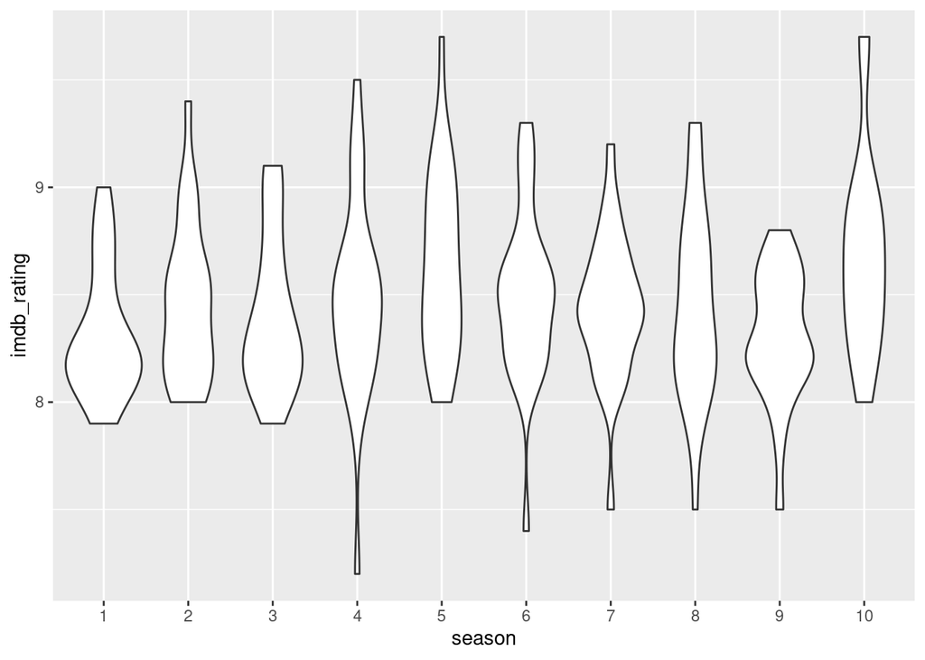

```r
#option number 2 - generate a boxplot or violin plot to look at the distribution of the ratings by season without having to specific run any data transformations.

friends_info$season <- as.factor(friends_info$season)
ggplot(friends_info, aes(season, imdb_rating))+
  #geom_boxplot()+
  geom_violin()
```

## How to Deal with NA’s (missing values)

Missing values can cause all sorts of headaches because many aggregation functions will output a missing value if a missing value in part of the input. There are two primary ways of getting around this issue. For more details on how to deal with missing values check out the second edition of R4DS (https://r4ds.hadley.nz/missing-values.html).

### The na.rm argument

The na.rm argument (found within all aggregation functions) removes the missing values prior to computation (aggregation).

```r
friends_info_na%>%
  group_by(directed_by)%>%
  summarise(mean_views = mean(us_views_millions, na.rm = TRUE))
```

```
## # A tibble: 31 × 2
##    directed_by          mean_views
##    <chr>                     <dbl>
##  1 Alan Myerson               25.8
##  2 Andrew Tsao                26
##  3 Arlene Sanford             18.2
##  4 Ben Weiss                  23.8
##  5 Dana DeValley Piazza       24.8
##  6 Dana DeVally Piazza        25.3
##  7 David Schwimmer            24.4
##  8 David Steinberg            23.7
##  9 Ellen Gittelsohn           28.3
## 10 Gail Mancuso               25.3
## # … with 21 more rows
```

```r
#note Gail Mancuso
```

### removing observations with missing values

In the dataset below, there are many missing values in the emotion column. I want to create a count of the number of time the main characters uttered each emotion.

```r
#create list for filter
target <- c ("Rachel Green", "Ross Geller", "Joey Tribbiani", "Chandler Bing", "Monica Geller", "Phoebe Buffay")


#option 1
friends_full%>%
  filter(speaker%in%target)%>%
  group_by(emotion, speaker)%>%
  drop_na()%>%
  summarise(n = n())%>%
  arrange(emotion, n)
```

```
## # A tibble: 42 × 3
## # Groups:   emotion [7]
##    emotion speaker            n
##    <chr>   <chr>          <int>
##  1 Joyful  Rachel Green     336
##  2 Joyful  Monica Geller    347
##  3 Joyful  Ross Geller      355
##  4 Joyful  Joey Tribbiani   387
##  5 Joyful  Phoebe Buffay    393
##  6 Joyful  Chandler Bing    412
##  7 Mad     Phoebe Buffay    125
##  8 Mad     Joey Tribbiani   138
##  9 Mad     Ross Geller      204
## 10 Mad     Monica Geller    220
## # … with 32 more rows
```

```r
#option 2
friends_full%>%
  filter(speaker%in%target,
         !is.na(emotion))%>%
  group_by(emotion, speaker)%>%
  summarise(n = n())%>%
  arrange(emotion, n)
```

```
## # A tibble: 42 × 3
## # Groups:   emotion [7]
##    emotion speaker            n
##    <chr>   <chr>          <int>
##  1 Joyful  Rachel Green     336
##  2 Joyful  Monica Geller    347
##  3 Joyful  Ross Geller      355
##  4 Joyful  Joey Tribbiani   387
##  5 Joyful  Phoebe Buffay    393
##  6 Joyful  Chandler Bing    412
##  7 Mad     Phoebe Buffay    125
##  8 Mad     Joey Tribbiani   138
##  9 Mad     Ross Geller      204
## 10 Mad     Monica Geller    220
## # … with 32 more rows
```

## Using DataEditR

One of the major benefits of using R in your research workflow is that it creates a scriptable / reproducible process but for beginners to R it can be hard to break old habits. Many of us have relied on GUI based spreadsheet programs (Excel) for so long it can be hard to think in R. **DataEditR** is package that can help your transition to R.

**DataEditR** is a package with a single function called data_edit() that creates an interactive data editor. Within this GUI editor you can:

- column selection using the `dataSelect` module
- row selection using the `dataFilter` module
- edit row or column names
- addition or removal of rows or columns
- manual column resizing
- drag to fill cells
- copy or paste data to and from external software
- custom column types to simplify user input (e.g. checkboxes and dropdown menus)
- support for readonly columns to prevent users from editing certain columns
- control over which column names can be edited
- stretch columns horizontally to fill available space
- programmatically add columns or rows to data prior to loading into the data editor

You can call up the interface by using the data_edit() function.

To create a new data file from an existing data frame use the following syntax:

```r
#friends_info_new <- data_edit(friends_info,save_as = "friends_info_new.csv")
```